# S1_F2_Preprocesamiento

## Notebook de obtención, limpieza y transformación de datos — Fase 2

**Proyecto:** Factores sociodemográficos y riesgo cardiovascular (ENS 2016-2017)

### ¿Qué es un *pipeline* de preprocesamiento?

Un *pipeline* es una secuencia ordenada de pasos por los que pasan los datos crudos hasta quedar listos para analizar. En este notebook el flujo es:

**Obtener → Explorar → Códigos especiales → Limpiar → Transformar → Escalar → Validar**

Cada paso se implementa como una **función** reutilizable. Trabajar con funciones (en vez de copiar y pegar código) hace el proceso más ordenado, más fácil de corregir y permite reutilizar la misma lógica sobre cualquier columna sin reescribirla.

## Introducción

Las enfermedades cardiovasculares (ECV) son la principal causa de muerte a nivel mundial: en 2023 provocaron 19,2 millones de fallecimientos, una de cada tres muertes globales, cifra que casi se ha duplicado desde los 13,1 millones registrados en 1990 (Global Burden of Disease, 2023). A esto se suma una carga considerable de discapacidad (437 millones de años de vida ajustados por discapacidad) y una prevalencia de hipertensión arterial que afecta a 1.280 millones de adultos entre 30 y 79 años en el mundo, de los cuales solo uno de cada cinco mantiene su condición controlada (OMS, 2023).

Chile no escapa a esta tendencia. Según la Encuesta Nacional de Salud (ENS) 2016-2017 del Ministerio de Salud, la prevalencia nacional de hipertensión arterial alcanza 27,6% y la de sospecha de diabetes mellitus 12,3% en personas de 15 años y más (MINSAL, 2017). Ambas cifras se ubican entre las más altas del conjunto de indicadores medidos por la encuesta, y sitúan a las ECV y sus factores de riesgo como una de las principales prioridades de salud pública del país.

Sin embargo, estas cifras agregadas no informan cómo se distribuye el riesgo al interior de la población. Este proyecto busca avanzar en esa dirección: investigar cómo se asocian las características sociodemográficas de las personas encuestadas —edad, sexo, educación, ingreso del hogar y zona de residencia— con los principales indicadores de riesgo cardiovascular disponibles en la ENS 2016-2017, aportando evidencia que permita comprender si el riesgo se concentra en subgrupos específicos de la población chilena.

**Objetivo general (Fase 2).** Construir un *pipeline* reproducible que deje el subconjunto seleccionado en Fase 1 limpio, codificado y escalado, listo para el análisis de asociaciones de las fases siguientes.

**Objetivos específicos.**

- Obtener el subconjunto de trabajo **siempre a partir del archivo original** `ens2016.xlsx`, seleccionando las 16 variables definidas en la Fase 1.
- Explorar la calidad de los datos y declarar el rol analítico de cada variable.
- Identificar y tratar los códigos especiales de no respuesta del libro de códigos ENS.
- Limpiar gestionando rigurosamente los valores nulos.
- Transformar las variables categóricas (codificación binaria/One-Hot) respetando su naturaleza nominal u ordinal.
- Estandarizar las variables continuas.
- Validar técnicamente el resultado y dejarlo disponible para la Fase 3.

**Variables (16):** `IdEncuesta`, `FechaInicioF1`, `Edad`, `Sexo`, `Zona`, `HTA`, `di3`, `dis2`, `IMC`, `anos_estudio_MINSAL_1`, `GPAQ`, `as27`, `as28`, `Fexp_F1F2p_Corr`, `Conglomerado`, `Estrato`.

### Librerías utilizadas

| Librería | Para qué la usamos |
| --- | --- |
| `numpy` | Cálculo numérico y manejo de arreglos. |
| `pandas` | Cargar y manipular la tabla de datos (el `DataFrame`). |
| `matplotlib` | Generar los gráficos (*boxplots*). |
| `sklearn.preprocessing` | Codificación (`LabelEncoder`, `OneHotEncoder`) y escalamiento (`StandardScaler`, `MinMaxScaler`, `RobustScaler`). |

`np.random.seed(2026)` fija la semilla aleatoria —la misma que usa el cuaderno de la Fase 1— para que cualquier proceso con azar dé **siempre el mismo resultado**.

```python
import numpy as np                  # calculo numerico y operaciones vectorizadas
import pandas as pd                 # estructuras tabulares: Series y DataFrame
import matplotlib.pyplot as plt     # graficos de control
from sklearn import preprocessing   # LabelEncoder y OneHotEncoder
from sklearn.preprocessing import StandardScaler, MinMaxScaler, RobustScaler

# Reproducibilidad: misma semilla que el cuaderno de la Fase 1
SEMILLA = 2026
np.random.seed(SEMILLA)

%matplotlib inline
```

## Configuración del entorno y de las rutas

Se reutiliza el mismo criterio que en la Fase 1: la raíz del proyecto se ubica buscando la carpeta `.git`, no adivinando cuántos niveles subir desde `F2/notebooks`. Así el cuaderno corre igual sin importar desde qué carpeta lo abra Jupyter, y las rutas quedan relativas al repositorio, no al computador de quien lo ejecuta.

```python
from pathlib import Path
import sys

print("Python:", sys.version.split()[0])
for lib, mod in [("numpy", np), ("pandas", pd)]:
    print(f"{lib:8}:", mod.__version__)


def encontrar_raiz_proyecto(marcador=".git") -> Path:
    """Sube por las carpetas padre hasta encontrar la raiz del repositorio."""
    actual = Path.cwd()
    for carpeta in [actual, *actual.parents]:
        if (carpeta / marcador).exists():
            return carpeta
    raise FileNotFoundError(f"No se encontro '{marcador}' en ningun directorio padre de {actual}")


RAIZ = encontrar_raiz_proyecto()
print("\nRaiz del proyecto detectada en:", RAIZ)

DIR_CRUDO = RAIZ / "data" / "raw"            # datos originales: nunca se modifican
DIR_PROCESADO = RAIZ / "data" / "processed"  # resultado del pipeline
DIR_DOCS = RAIZ / "F2" / "docs"              # diccionario, resumenes y metadatos de F2
for carpeta in (DIR_CRUDO, DIR_PROCESADO, DIR_DOCS):
    carpeta.mkdir(parents=True, exist_ok=True)

ARCHIVO_ORIGEN = DIR_CRUDO / "ens2016.xlsx"
print("\nArchivo origen esperado en:", ARCHIVO_ORIGEN)
print("¿Existe?", ARCHIVO_ORIGEN.exists())
```

```
Python: 3.13.9
numpy   : 2.5.3
pandas  : 3.0.5

Raiz del proyecto detectada en: /Users/felipekaysdiaztoro/proyecto-grupo4-mcdi500

Archivo origen esperado en: /Users/felipekaysdiaztoro/proyecto-grupo4-mcdi500/data/raw/ens2016.xlsx
¿Existe? True
```

### Procedencia del conjunto de datos

| Campo | Valor |
| --- | --- |
| Título | Encuesta Nacional de Salud (ENS) 2016–2017 |
| Autor / responsable | Ministerio de Salud de Chile (MINSAL), Departamento de Epidemiología |
| Plataforma | MINSAL — Repositorio de encuestas de salud |
| Estructura del archivo original | 6.233 filas × 1.173 columnas |
| Subconjunto de trabajo (Fase 1) | 16 variables seleccionadas, filtradas por ponderador válido |
| Unidad de observación | Persona encuestada residente en Chile |

**Referencia en APA 7 para el informe:**

> Ministerio de Salud de Chile (MINSAL), Departamento de Epidemiología. (2017). *Encuesta Nacional de Salud 2016–2017* [Conjunto de datos]. Gobierno de Chile.

Documentar la procedencia no es un trámite: sin ella, nadie puede verificar sobre qué versión del archivo se trabajó.

## 1. Obtención de los datos

**Qué hace este paso.** A diferencia de leer directamente un archivo ya recortado, aquí la base **siempre** es `data/raw/ens2016.xlsx` sin modificar. De ese archivo se seleccionan las 16 variables que se definieron y justificaron en la Fase 1, y luego se conserva únicamente a las personas con un ponderador `Fexp_F1F2p_Corr` válido (numérico, mayor que cero, sin infinitos ni vacíos) — el mismo criterio de elegibilidad F1–F2 usado en la Fase 1.

**Por qué con funciones.** `seleccionar_variables_ens` valida que las 16 columnas existan antes de recortar la tabla (si faltara una, se detiene con un mensaje claro en vez de fallar más adelante de forma confusa). `filtrar_ponderador_valido` aísla la regla de elegibilidad en un solo lugar, para no repetirla ni describirla de memoria en el informe.

```python
VARIABLES = [
    "IdEncuesta", "FechaInicioF1", "Edad", "Sexo", "Zona", "HTA", "di3", "dis2",
    "IMC", "anos_estudio_MINSAL_1", "GPAQ", "as27", "as28", "Fexp_F1F2p_Corr",
    "Conglomerado", "Estrato",
]


def seleccionar_variables_ens(ruta_origen, variables):
    """
    Lee la base origen de la ENS y recorta las columnas indicadas.

    No cambia codigos ni excluye registros: es una seleccion de COLUMNAS,
    coherente con la caracterizacion de variables hecha en la Fase 1.

    Lanza
    -----
    FileNotFoundError
        Si el archivo origen no existe.
    ValueError
        Si falta alguna variable esperada en la base origen.
    """
    if not Path(ruta_origen).exists():
        raise FileNotFoundError(f"No se encontro la base origen en:\n{ruta_origen}")

    base = pd.read_excel(ruta_origen, sheet_name="Sheet1")
    faltantes = [v for v in variables if v not in base.columns]
    if faltantes:
        raise ValueError(f"No se encontraron estas variables en la base origen: {faltantes}")

    print(f"Base origen: {base.shape[0]} filas x {base.shape[1]} columnas")
    return base[variables].copy()


seleccion = seleccionar_variables_ens(ARCHIVO_ORIGEN, VARIABLES)
print(f"Seleccion (16 variables): {seleccion.shape[0]} filas x {seleccion.shape[1]} columnas")

ARCHIVO_SELECCIONADAS = DIR_PROCESADO / "ens_variables_seleccionadas.xlsx"
seleccion.to_excel(ARCHIVO_SELECCIONADAS, index=False)
print(f"Guardado: {ARCHIVO_SELECCIONADAS}")
```

```
Base origen: 6233 filas x 1173 columnas
Seleccion (16 variables): 6233 filas x 16 columnas
Guardado: /Users/felipekaysdiaztoro/proyecto-grupo4-mcdi500/data/processed/ens_variables_seleccionadas.xlsx
```

Con las 16 variables recortadas, se aplica el filtro de elegibilidad F1–F2: no toda persona encuestada en la Fase 1 fue re-contactada en la Fase 2, y quienes no lo fueron no tienen un ponderador combinado válido para analizarlas en conjunto.

```python
def filtrar_ponderador_valido(df, columna_peso):
    """
    Conserva solo las filas con ponderador valido: numerico, > 0, finito y no nulo.

    Retorna
    -------
    tuple(pd.DataFrame, pd.DataFrame)
        El subconjunto filtrado y una tabla resumen del filtro (trazabilidad).
    """
    peso = pd.to_numeric(df[columna_peso], errors="coerce")
    valido = peso.notna() & peso.gt(0) & peso.lt(float("inf"))

    filtrado = df.loc[valido].copy()
    filtrado[columna_peso] = peso.loc[valido]

    resumen = pd.DataFrame({
        "indicador": [
            "Personas antes del filtro",
            "Personas con ponderador valido",
            "Personas excluidas por ponderador no valido",
            "Suma de ponderadores del subconjunto",
        ],
        "valor": [
            len(df), len(filtrado), len(df) - len(filtrado), filtrado[columna_peso].sum(),
        ],
    })
    return filtrado, resumen


seleccion_f1f2, resumen_filtro = filtrar_ponderador_valido(seleccion, "Fexp_F1F2p_Corr")

ARCHIVO_F1F2 = DIR_PROCESADO / "ens_variables_f1f2.xlsx"
seleccion_f1f2.to_excel(ARCHIVO_F1F2, index=False)
resumen_filtro.to_csv(DIR_DOCS / "resumen_filtro_f1f2.csv", index=False)

print(f"Guardado: {ARCHIVO_F1F2}")
resumen_filtro
```

```
Guardado: /Users/felipekaysdiaztoro/proyecto-grupo4-mcdi500/data/processed/ens_variables_f1f2.xlsx
```

|  | indicador | valor |
| --- | --- | --- |
| 0 | Personas antes del filtro | 6.233000e+03 |
| 1 | Personas con ponderador valido | 5.520000e+03 |
| 2 | Personas excluidas por ponderador no valido | 7.130000e+02 |
| 3 | Suma de ponderadores del subconjunto | 1.451897e+07 |

> **Trazabilidad con la Fase 1.** El cuaderno `F1/notebooks/S1_F1_Definicion.ipynb` reconoce y verifica este mismo archivo (`data/processed/ens_variables_f1f2.xlsx`) al auditar la estructura del repositorio. Regenerarlo aquí, siempre desde `ens2016.xlsx`, evita que ambas fases queden documentando un archivo que alguien pudo haber editado a mano en el camino.

```python
# df_crudo es el punto de partida SIN limpiar: se usa mas adelante para comparar
# el efecto de cada transformacion contra el estado original.
df_crudo = seleccion_f1f2.reset_index(drop=True)
df = df_crudo.copy()

print(f"Filas: {df.shape[0]}")
print(f"Columnas: {df.shape[1]}")
df.head()
```

```
Filas: 5520
Columnas: 16
```

|  | IdEncuesta | FechaInicioF1 | Edad | Sexo | Zona | HTA | di3 | dis2 | IMC | anos_estudio_MINSAL_1 | GPAQ | as27 | as28 | Fexp_F1F2p_Corr | Conglomerado | Estrato |
| --- | --- | --- | --- | --- | --- | --- | --- | --- | --- | --- | --- | --- | --- | --- | --- | --- |
| 0 | 20008 | 2016-11-27 15:10:40 | 25 | 2 | 1 | 0.0 | 2 | 3 | 23.198208 | 15.0 | 3.0 | 200000.0 | 3 | 52.307503 | 13101101 | 131 |
| 1 | 20011 | 2016-11-26 15:52:49 | 20 | 2 | 1 | 0.0 | 2 | 3 | 26.203983 | 14.0 | 3.0 | NaN | -9999 | 250.753357 | 13101102 | 131 |
| 2 | 20012 | 2016-11-20 13:16:39 | 85 | 2 | 1 | 1.0 | 2 | 2 | 23.732346 | 15.0 | 1.0 | 1300000.0 | 10 | 133.128342 | 13101102 | 131 |
| 3 | 20017 | 2016-12-02 15:25:24 | 30 | 2 | 1 | 0.0 | 2 | 3 | 25.015243 | 16.0 | 3.0 | NaN | -9999 | 140.833298 | 13101102 | 131 |
| 4 | 20018 | 2016-11-26 16:02:05 | 53 | 2 | 1 | 0.0 | 2 | 3 | 32.290249 | 14.0 | 1.0 | NaN | -9999 | 97.582199 | 13101102 | 131 |

## 2. Exploración inicial

**Qué hace este paso.** Antes de modificar nada, miramos el estado original de los datos. Esto da la "línea base" contra la cual se verifica después cada transformación.

La función `explorar_dataframe` reporta dimensiones, tipos de datos, nulos por columna y estadísticos descriptivos de las variables numéricas.

```python
def explorar_dataframe(datos):
    """Resumen exploratorio: dimensiones, tipos, nulos y estadisticos descriptivos."""
    print("Dimensiones:", datos.shape)
    print("\nTipos de datos:")
    print(datos.dtypes)
    print("\nValores nulos por columna:")
    print(datos.isnull().sum())
    print("\nEstadisticos descriptivos (variables numericas):")
    return datos.describe()


explorar_dataframe(df)
```

```
Dimensiones: (5520, 16)

Tipos de datos:
IdEncuesta                        int64
FechaInicioF1            datetime64[us]
Edad                              int64
Sexo                              int64
Zona                              int64
HTA                             float64
di3                               int64
dis2                              int64
IMC                             float64
anos_estudio_MINSAL_1           float64
GPAQ                            float64
as27                            float64
as28                              int64
Fexp_F1F2p_Corr                 float64
Conglomerado                      int64
Estrato                           int64
dtype: object

Valores nulos por columna:
IdEncuesta                 0
FechaInicioF1              0
Edad                       0
Sexo                       0
Zona                       0
HTA                        9
di3                        0
dis2                       0
IMC                       37
anos_estudio_MINSAL_1     47
GPAQ                     196
as27                     995
as28                       0
Fexp_F1F2p_Corr            0
Conglomerado               0
Estrato                    0
dtype: int64

Estadisticos descriptivos (variables numericas):
```

|  | IdEncuesta | FechaInicioF1 | Edad | Sexo | Zona | HTA | di3 | dis2 | IMC | anos_estudio_MINSAL_1 | GPAQ | as27 | as28 | Fexp_F1F2p_Corr | Conglomerado | Estrato |
| --- | --- | --- | --- | --- | --- | --- | --- | --- | --- | --- | --- | --- | --- | --- | --- | --- |
| count | 5520.000000 | 5520 | 5520.000000 | 5520.000000 | 5520.000000 | 5511.000000 | 5520.000000 | 5520.000000 | 5483.000000 | 5473.000000 | 5324.000000 | 4.525000e+03 | 5520.000000 | 5520.000000 | 5.520000e+03 | 5520.000000 |
| mean | 25781.190580 | 2016-11-07 22:08:31.675181 | 49.202536 | 1.634239 | 1.158514 | 0.362911 | 1.861413 | 2.654167 | 28.932581 | 10.092271 | 1.941397 | 4.693827e+05 | -1477.188043 | 2630.248003 | 8.561019e+06 | 84.845109 |
| min | 20008.000000 | 2016-08-04 12:16:22 | 15.000000 | 1.000000 | 1.000000 | 0.000000 | 1.000000 | 1.000000 | 14.756944 | 0.000000 | 1.000000 | 2.000000e+04 | -9999.000000 | 3.130555 | 1.101101e+06 | 11.000000 |
| 25% | 22672.750000 | 2016-10-14 12:26:29.250000 | 33.000000 | 1.000000 | 1.000000 | 0.000000 | 2.000000 | 2.000000 | 25.061417 | 8.000000 | 1.000000 | 2.000000e+05 | 3.000000 | 454.584778 | 5.304202e+06 | 51.000000 |
| 50% | 25751.500000 | 2016-11-05 15:50:20 | 50.000000 | 2.000000 | 1.000000 | 0.000000 | 2.000000 | 3.000000 | 28.316742 | 11.000000 | 2.000000 | 3.000000e+05 | 5.000000 | 1209.348022 | 8.301201e+06 | 81.000000 |
| 75% | 28504.250000 | 2016-11-27 15:56:07 | 64.000000 | 2.000000 | 1.000000 | 1.000000 | 2.000000 | 3.000000 | 32.011628 | 12.000000 | 3.000000 | 5.000000e+05 | 7.000000 | 3017.059387 | 1.310210e+07 | 131.000000 |
| max | 70000.000000 | 2017-02-23 18:03:30 | 98.000000 | 2.000000 | 2.000000 | 1.000000 | 3.000000 | 4.000000 | 63.510653 | 22.000000 | 3.000000 | 1.600000e+07 | 11.000000 | 24000.000000 | 1.510120e+07 | 152.000000 |
| std | 3685.647171 | NaN | 19.266931 | 0.481687 | 0.365256 | 0.480883 | 0.371327 | 0.776163 | 5.575040 | 4.285251 | 0.875675 | 6.241833e+05 | 3554.730780 | 3888.858897 | 4.150368e+06 | 41.745054 |

También revisamos **cuántas categorías distintas** tiene cada variable candidata a nominal, ordinal o binaria, y cuántas veces aparece cada una. `dropna=False` incluye los nulos como una categoría más: si una variable tiene faltantes se quiere verlos aquí, no que desaparezcan del conteo.

```python
columnas_categoricas = ["Sexo", "Zona", "di3", "dis2", "GPAQ", "as28"]
for col in columnas_categoricas:
    print(f"\n{col}:")
    print(df[col].value_counts(dropna=False).sort_index())
```

```
Sexo:
Sexo
1    2019
2    3501
Name: count, dtype: int64

Zona:
Zona
1    4645
2     875
Name: count, dtype: int64

di3:
di3
1     816
2    4653
3      51
Name: count, dtype: int64

dis2:
dis2
1     767
2     646
3    3836
4     271
Name: count, dtype: int64

GPAQ:
GPAQ
1.0    2206
2.0    1224
3.0    1894
NaN     196
Name: count, dtype: int64

as28:
as28
-9999    818
 1       102
 2       421
 3       752
 4       641
 5       782
 6       518
 7       634
 8       206
 9       364
 10      142
 11      140
Name: count, dtype: int64
```

### El diccionario de variables

Antes de limpiar hay que declarar **qué es cada variable**. En este conjunto, `Sexo`, `di3` e `IdEncuesta` son todas numéricas y sin embargo exigen tratamientos completamente distintos: el rol analítico no lo dice el `dtype`, lo decide el equipo.

| Rol analítico | Qué preprocesamiento exige |
| --- | --- |
| **Continua** | Detección de atípicos, imputación, escalamiento |
| **Discreta** | Imputación; no siempre requiere escalamiento |
| **Binaria** | Codificación 0/1 y revisión de desbalance |
| **Nominal** | *One-hot encoding* |
| **Ordinal** | Se conserva el orden — no se aplica *one-hot* |
| **Identificador** | Verificar unicidad y excluir del análisis |
| **Fecha** | Se documenta; se excluye de la matriz de variables explicativas |

Los roles de la tabla siguiente son los que **el equipo declaró** en la Fase 1 (`CLASIFICACION_EQUIPO`, contrastado ya contra el validador automático en `docs/informe_validacion_f1f2.md`), con una excepción documentada más abajo: `GPAQ` se reclasifica de *nominal* a *ordinal* en este cuaderno.

```python
# Rol asignado por el equipo en la Fase 1 (ver docs/informe_validacion_f1f2.md).
# GPAQ se corrige aqui de "nominal" a "ordinal": el nivel de actividad fisica
# (Bajo < Moderado < Alto) tiene un orden con sentido en el dominio, y tratarlo
# como nominal perderia esa informacion al codificarlo. Ver seccion 5.
DECLARADO = [
    ("IdEncuesta",             "identificador", "Identificador unico de la persona encuestada"),
    ("FechaInicioF1",          "fecha",         "Fecha y hora de inicio de la entrevista F1"),
    ("Edad",                   "continua",      "Edad en anios"),
    ("Sexo",                   "binaria",       "1 = Hombre, 2 = Mujer"),
    ("Zona",                   "binaria",       "1 = Urbano, 2 = Rural"),
    ("HTA",                    "binaria",       "1 = hipertension arterial diagnosticada"),
    ("di3",                    "nominal",       "Diagnostico de diabetes (codigos 1/2/3, ver libro de codigos)"),
    ("dis2",                   "nominal",       "Diagnostico de colesterol alto (codigos 1 a 4, ver libro de codigos)"),
    ("IMC",                    "continua",      "Indice de masa corporal"),
    ("anos_estudio_MINSAL_1",  "discreta",      "Anios de escolaridad"),
    ("GPAQ",                   "ordinal",       "Nivel de actividad fisica: 1 Bajo < 2 Moderado < 3 Alto"),
    ("as27",                   "continua",      "Ingreso total del hogar (pesos chilenos)"),
    ("as28",                   "ordinal",       "Tramo de ingreso per capita (1 a 11, orden creciente)"),
    ("Fexp_F1F2p_Corr",        "continua",      "Ponderador muestral combinado F1-F2 (diseno, no predictor)"),
    ("Conglomerado",           "identificador", "Conglomerado del diseno muestral (diseno, no predictor)"),
    ("Estrato",                "identificador", "Estrato del diseno muestral (diseno, no predictor)"),
]
diccionario = pd.DataFrame(DECLARADO, columns=["variable", "rol", "descripcion"])

# Columnas OBSERVADAS: se leen del archivo, no se escriben a mano
diccionario["dtype"] = [str(df_crudo[v].dtype) for v in diccionario["variable"]]
diccionario["n_unicos"] = [int(df_crudo[v].nunique()) for v in diccionario["variable"]]
diccionario["pct_nulos"] = [round(df_crudo[v].isna().mean() * 100, 1)
                            for v in diccionario["variable"]]

diccionario.to_csv(DIR_DOCS / "diccionario_variables.csv", index=False)
diccionario
```

|  | variable | rol | descripcion | dtype | n_unicos | pct_nulos |
| --- | --- | --- | --- | --- | --- | --- |
| 0 | IdEncuesta | identificador | Identificador unico de la persona encuestada | int64 | 5520 | 0.0 |
| 1 | FechaInicioF1 | fecha | Fecha y hora de inicio de la entrevista F1 | datetime64[us] | 5512 | 0.0 |
| 2 | Edad | continua | Edad en anios | int64 | 83 | 0.0 |
| 3 | Sexo | binaria | 1 = Hombre, 2 = Mujer | int64 | 2 | 0.0 |
| 4 | Zona | binaria | 1 = Urbano, 2 = Rural | int64 | 2 | 0.0 |
| 5 | HTA | binaria | 1 = hipertension arterial diagnosticada | float64 | 2 | 0.2 |
| 6 | di3 | nominal | Diagnostico de diabetes (codigos 1/2/3, ver li... | int64 | 3 | 0.0 |
| 7 | dis2 | nominal | Diagnostico de colesterol alto (codigos 1 a 4,... | int64 | 4 | 0.0 |
| 8 | IMC | continua | Indice de masa corporal | float64 | 5332 | 0.7 |
| 9 | anos_estudio_MINSAL_1 | discreta | Anios de escolaridad | float64 | 23 | 0.9 |
| 10 | GPAQ | ordinal | Nivel de actividad fisica: 1 Bajo < 2 Moderado... | float64 | 3 | 3.6 |
| 11 | as27 | continua | Ingreso total del hogar (pesos chilenos) | float64 | 254 | 18.0 |
| 12 | as28 | ordinal | Tramo de ingreso per capita (1 a 11, orden cre... | int64 | 12 | 0.0 |
| 13 | Fexp_F1F2p_Corr | continua | Ponderador muestral combinado F1-F2 (diseno, n... | float64 | 4764 | 0.0 |
| 14 | Conglomerado | identificador | Conglomerado del diseno muestral (diseno, no p... | int64 | 1075 | 0.0 |
| 15 | Estrato | identificador | Estrato del diseno muestral (diseno, no predic... | int64 | 30 | 0.0 |

Sobre di3 y dis2. Sus categorías minoritarias no son códigos de no respuesta (`-8888`/`-9999`) — eso se verifica en la sección siguiente —, sino respuestas válidas según el libro de códigos F1 de la ENS 2016–2017: `di3 = 3` es "No recuerda" y `dis2 = 4` es "No recuerda" (`dis2 = 3` significa "Nunca", una respuesta negativa válida, no incertidumbre). Se conservan como categorías propias del one-hot (sección 5), con su nombre real, en vez de fusionarlas con "No"/"Nunca" o de descartarlas.

### Valores atípicos: medir antes de decidir

Se usa el criterio del rango intercuartílico sobre las tres variables continuas (`Edad`, `IMC`, `as27`):

$$\text{atípico si} \quad x < Q_1 - 1{,}5 \cdot \text{RIC} \quad \text{o} \quad x > Q_3 + 1{,}5 \cdot \text{RIC}$$

```python
def detectar_atipicos_iqr(serie, factor=1.5):
    """Identifica valores atipicos por el criterio del rango intercuartilico.

    Retorna
    -------
    tuple(np.ndarray, float, float)
        Mascara booleana de atipicos, limite inferior y limite superior.
    """
    valores = serie.dropna().to_numpy(dtype="float64")
    q1, q3 = np.percentile(valores, [25, 75])
    ric = q3 - q1
    limite_inf, limite_sup = q1 - factor * ric, q3 + factor * ric

    mascara = (serie < limite_inf) | (serie > limite_sup)
    return mascara.fillna(False).to_numpy(), limite_inf, limite_sup


filas = []
for col in ["Edad", "IMC", "as27"]:
    mascara, inf, sup = detectar_atipicos_iqr(df[col])
    filas.append({
        "variable": col,
        "limite_inf": round(inf, 2),
        "limite_sup": round(sup, 2),
        "n_atipicos": int(mascara.sum()),
        "pct_atipicos": round(mascara.mean() * 100, 2),
        "media": round(df[col].mean(), 2),
        "mediana": round(df[col].median(), 2),
    })
pd.DataFrame(filas)
```

|  | variable | limite_inf | limite_sup | n_atipicos | pct_atipicos | media | mediana |
| --- | --- | --- | --- | --- | --- | --- | --- |
| 0 | Edad | -13.50 | 110.50 | 0 | 0.00 | 49.20 | 50.00 |
| 1 | IMC | 14.64 | 42.44 | 115 | 2.08 | 28.93 | 28.32 |
| 2 | as27 | -250000.00 | 950000.00 | 405 | 7.34 | 469382.67 | 300000.00 |

> **Cómo se lee esta tabla.** En `as27` (ingreso del hogar) la media queda muy por encima de la mediana: unos pocos hogares con ingresos extremos arrastran el promedio. Ese es el argumento técnico para imputar con la mediana en la sección de limpieza, no una preferencia por defecto.

## 3. Códigos especiales de no respuesta

Antes de imputar nada hay que distinguir un **valor faltante real** (`NaN`) de un **código de no respuesta**: un entero válido desde el punto de vista de pandas (`-8888` o `-9999`) que en el libro de códigos F1/F2 de la ENS significa "No sabe" o "No responde" respectivamente. Si no se detectan, `pandas.isna()` los deja pasar como si fueran datos numéricos legítimos y contaminan cualquier estadístico o imputación posterior.

Se revisan las seis variables candidatas —`as27`, `as28`, `di3`, `dis2`, `HTA`, `GPAQ`— **sin asumir que todas usan el mismo esquema**: cada una se cuenta por separado.

```python
def revisar_codigos_especiales(df, columnas, codigos=(-8888, -9999)):
    """Cuenta cuantas veces aparece cada codigo especial en cada columna."""
    filas = []
    for col in columnas:
        conteo = {"variable": col}
        for cod in codigos:
            conteo[f"n_{cod}"] = int((df[col] == cod).sum())
        filas.append(conteo)
    return pd.DataFrame(filas)


variables_a_revisar = ["as27", "as28", "di3", "dis2", "HTA", "GPAQ"]
revisar_codigos_especiales(df, variables_a_revisar)
```

|  | variable | n_-8888 | n_-9999 |
| --- | --- | --- | --- |
| 0 | as27 | 0 | 0 |
| 1 | as28 | 0 | 818 |
| 2 | di3 | 0 | 0 |
| 3 | dis2 | 0 | 0 |
| 4 | HTA | 0 | 0 |
| 5 | GPAQ | 0 | 0 |

**Resultado.** De las seis variables candidatas, solo `as28` contiene efectivamente el código `-9999` (no aparece `-8888` en ninguna). Es una comprobación, no un supuesto: las demás variables no necesitan este tratamiento, y aplicárselo igual sin verificar habría sido un paso de limpieza injustificado.

Se reemplaza `-9999` por `NaN` en `as28` y, como el hecho de no responder puede ser informativo en sí mismo (a diferencia de un olvido aleatorio), se conserva en una columna aparte antes de imputar — el mismo criterio que la bandera `bmi_imputado` del patrón visto en el curso.

```python
def marcar_codigos_no_respuesta(df, columna, codigos=(-8888, -9999)):
    """
    Reemplaza los codigos de no respuesta indicados por NaN en una columna.

    Retorna
    -------
    pd.DataFrame
        Copia del DataFrame con la columna corregida.
    """
    if columna not in df.columns:
        raise KeyError(f"La columna '{columna}' no existe en el DataFrame.")
    df = df.copy()
    es_codigo = df[columna].isin(codigos)
    n = int(es_codigo.sum())
    df.loc[es_codigo, columna] = np.nan
    print(f"'{columna}': {n} valores con codigo de no respuesta marcados como NaN")
    return df


df["as28_no_responde"] = df["as28"].isin([-8888, -9999]).astype(int)
df = marcar_codigos_no_respuesta(df, "as28")
```

```
'as28': 818 valores con codigo de no respuesta marcados como NaN
```

## 4. Limpieza de datos

Se toman seis decisiones, cada una justificada con las cifras ya obtenidas:

**a) Excluir identificadores.** `IdEncuesta` es un identificador único de persona: no aporta información predictiva. `Conglomerado` y `Estrato` son variables de **diseño muestral** (identifican el conglomerado y estrato de muestreo), no predictoras — se conservan en el archivo final para que la Fase 3 pueda usarlas en un análisis con diseño muestral, pero quedan fuera de cualquier transformación (no se codifican ni escalan). `FechaInicioF1` (fecha) tampoco es una variable explicativa del riesgo cardiovascular en este alcance, así que se excluye de la matriz que se transforma más abajo.

**b) Eliminar las filas con `HTA` nulo.** Son 9 personas (0,16 % de la muestra) sin diagnóstico de hipertensión registrado. A diferencia de `bmi` en el ejemplo del curso, `HTA` es un diagnóstico clínico binario: imputarlo (con la moda, que sería "No") equivale a afirmar que esas 9 personas no tienen hipertensión sin que nadie lo haya reportado. Con una fracción tan pequeña de la muestra, eliminar las filas es más defendible que inventar un diagnóstico.

**c) Imputar `IMC` y `anos_estudio_MINSAL_1` con la mediana simple; `as27` con un tratamiento dividido (detalle en la sección 2).** `IMC` y `anos_estudio_MINSAL_1` tienen nulos reales con distribuciones asimétricas y se imputan con la mediana global. `as27` es distinto: 816 de sus nulos (en el conjunto de trabajo, ya sin las 9 filas de la decisión b) son la misma no respuesta económica de `as28` (decisión e) y no se imputan; los 177 restantes sí declararon su tramo de ingreso y se imputan con la mediana de `as27` dentro de ese tramo.

**d) Imputar `GPAQ` con la moda.** Para una variable ordinal, la moda conserva una categoría observada real en la escala, a diferencia de una imputación numérica tipo mediana. Este criterio no se aplica igual a todas las variables ordinales con nulos: se evalúa caso a caso según qué tan verificable es el patrón de no respuesta y qué tan costoso sería imputar mal (ver la decisión sobre `as28` a continuación, que sigue un criterio distinto). Para `GPAQ` específicamente no hay evidencia verificada de un patrón de no respuesta — solo la duda razonable sobre su procedencia, ya que no aparece documentado como variable cruda en el libro de códigos y es probablemente un índice ya calculado por MINSAL según el protocolo GPAQ de la OMS — y el costo de imputar mal es bajo: apenas 3,6 % de nulos (196 de 5.520), con `GPAQ = 1` (Bajo) ya como categoría mayoritaria (41,4 %) entre quienes sí respondieron.

**e) No imputar `as28`.** El conjunto elegible tenía 818 registros con código `-9999` ("No responde") en `as28`; 816 de ellos siguen en el conjunto de trabajo tras excluir las 9 filas de la decisión b. Ninguno de esos 816 tiene un valor válido en `as27` (monto de ingreso del hogar): son exactamente los mismos casos, no dos fallas independientes. Quien no informa el monto tampoco informa el tramo — es la misma no respuesta económica, con un patrón que podría no ser aleatorio (concentrado en ingresos muy altos o muy bajos). Imputar con la moda escondería ese posible sesgo bajo un valor típico inventado. Se deja como faltante genuino (`NaN`) para que la Fase 3 decida su tratamiento con pleno conocimiento de esta limitación; la no respuesta ya queda registrada aparte en `as28_no_responde` (sección 3), sin necesidad de tocar la escala ordinal de `as28`.

**f) `di3`, `dis2`, `Sexo`, `Zona` no tienen nulos reales**: no requieren imputación.

```python
def imputar_nulos_numericos(df, columna, estrategia="mediana"):
    """
    Imputa los valores nulos de una columna numerica continua o discreta.

    Parametros
    ----------
    df : pd.DataFrame
    columna : str
    estrategia : str
        'media' o 'mediana'.

    Retorna
    -------
    pd.DataFrame
    """
    if columna not in df.columns:
        raise KeyError(f"La columna '{columna}' no existe en el DataFrame.")
    n_nulos = int(df[columna].isnull().sum())
    if estrategia == "media":
        valor = df[columna].mean()
    elif estrategia == "mediana":
        valor = df[columna].median()
    else:
        raise ValueError("estrategia debe ser 'media' o 'mediana'")
    df = df.copy()
    df[columna] = df[columna].fillna(valor)
    print(f"'{columna}': {n_nulos} nulos imputados con la {estrategia} = {valor:.2f}")
    return df


def imputar_nulos_categoricos(df, columna, estrategia="moda"):
    """
    Imputa los valores nulos de una columna categorica (nominal u ordinal) con la moda.

    Retorna
    -------
    pd.DataFrame
    """
    if columna not in df.columns:
        raise KeyError(f"La columna '{columna}' no existe en el DataFrame.")
    if estrategia != "moda":
        raise ValueError("estrategia debe ser 'moda'")
    n_nulos = int(df[columna].isnull().sum())
    valor = df[columna].mode(dropna=True).iloc[0]
    df = df.copy()
    df[columna] = df[columna].fillna(valor)
    print(f"'{columna}': {n_nulos} nulos imputados con la moda = {valor}")
    return df
```

**Antes** de limpiar, confirmamos dónde están los nulos:

```python
df.isnull().sum()
```

```
IdEncuesta                 0
FechaInicioF1              0
Edad                       0
Sexo                       0
Zona                       0
HTA                        9
di3                        0
dis2                       0
IMC                       37
anos_estudio_MINSAL_1     47
GPAQ                     196
as27                     995
as28                     818
Fexp_F1F2p_Corr            0
Conglomerado               0
Estrato                    0
as28_no_responde           0
dtype: int64
```

Excluimos el identificador `IdEncuesta` de la matriz de variables (se verifica antes que sea efectivamente único):

```python
assert df["IdEncuesta"].is_unique, "'IdEncuesta' tiene valores repetidos: revisar antes de descartarlo"
df = df.drop(columns=["IdEncuesta", "FechaInicioF1"])
df.head()
```

|  | Edad | Sexo | Zona | HTA | di3 | dis2 | IMC | anos_estudio_MINSAL_1 | GPAQ | as27 | as28 | Fexp_F1F2p_Corr | Conglomerado | Estrato | as28_no_responde |
| --- | --- | --- | --- | --- | --- | --- | --- | --- | --- | --- | --- | --- | --- | --- | --- |
| 0 | 25 | 2 | 1 | 0.0 | 2 | 3 | 23.198208 | 15.0 | 3.0 | 200000.0 | 3.0 | 52.307503 | 13101101 | 131 | 0 |
| 1 | 20 | 2 | 1 | 0.0 | 2 | 3 | 26.203983 | 14.0 | 3.0 | NaN | NaN | 250.753357 | 13101102 | 131 | 1 |
| 2 | 85 | 2 | 1 | 1.0 | 2 | 2 | 23.732346 | 15.0 | 1.0 | 1300000.0 | 10.0 | 133.128342 | 13101102 | 131 | 0 |
| 3 | 30 | 2 | 1 | 0.0 | 2 | 3 | 25.015243 | 16.0 | 3.0 | NaN | NaN | 140.833298 | 13101102 | 131 | 1 |
| 4 | 53 | 2 | 1 | 0.0 | 2 | 3 | 32.290249 | 14.0 | 1.0 | NaN | NaN | 97.582199 | 13101102 | 131 | 1 |

Eliminamos las filas con `HTA` nulo:

```python
n_antes = len(df)
df = df.dropna(subset=["HTA"]).reset_index(drop=True)
print(f"Filas eliminadas por 'HTA' nulo: {n_antes - len(df)}")
print(f"Filas restantes: {len(df)}")
```

```
Filas eliminadas por 'HTA' nulo: 9
Filas restantes: 5511
```

Imputamos `IMC` con la mediana:

```python
df = imputar_nulos_numericos(df, "IMC", estrategia="mediana")
```

```
'IMC': 37 nulos imputados con la mediana = 28.31
```

### Comparar los métodos antes de elegir en `as27`

`as27` (ingreso del hogar) es la variable con más nulos reales (18 %) y con los atípicos más extremos detectados en la sección 2. La función siguiente compara cuatro estrategias, incluida una imputación por grupo de edad, antes de aplicar una.

```python
def comparar_imputaciones(datos, columna, agrupador=None, n_grupos=4):
    """Compara el efecto de varias estrategias de imputacion sobre una variable.

    Retorna
    -------
    pd.DataFrame con el efecto de cada estrategia sobre la distribucion.
    """
    original = datos[columna]
    if original.isna().sum() == 0:
        raise ValueError(f"'{columna}' no tiene valores faltantes.")

    resultados = {
        "sin imputar (referencia)": original.dropna(),
        "eliminar filas": original.dropna(),
        "media": original.fillna(original.mean()),
        "mediana": original.fillna(original.median()),
    }
    if agrupador is not None:
        tramos = pd.qcut(datos[agrupador], q=n_grupos, duplicates="drop")
        resultados["mediana por grupo"] = original.fillna(
            original.groupby(tramos, observed=True).transform("median"))

    filas = [{
        "estrategia": nombre,
        "n": len(serie.dropna()),
        "media": round(serie.mean(), 3),
        "desv_est": round(serie.std(), 3),
        "asimetria": round(serie.skew(), 3),
    } for nombre, serie in resultados.items()]

    tabla = pd.DataFrame(filas)
    referencia = tabla.iloc[0]["desv_est"]
    tabla["cambio_desv_%"] = ((tabla["desv_est"] - referencia) / referencia * 100).round(2)
    tabla["filas_perdidas"] = len(datos) - tabla["n"]
    return tabla


comparar_imputaciones(df_crudo, "as27", agrupador="Edad")
```

|  | estrategia | n | media | desv_est | asimetria | cambio_desv_% | filas_perdidas |
| --- | --- | --- | --- | --- | --- | --- | --- |
| 0 | sin imputar (referencia) | 4525 | 469382.671 | 624183.272 | 11.315 | 0.00 | 995 |
| 1 | eliminar filas | 4525 | 469382.671 | 624183.272 | 11.315 | 0.00 | 995 |
| 2 | media | 5520 | 469382.671 | 565123.317 | 12.497 | -9.46 | 0 |
| 3 | mediana | 5520 | 438850.831 | 568862.464 | 12.408 | -8.86 | 0 |
| 4 | mediana por grupo | 5520 | 445622.570 | 568110.839 | 12.422 | -8.98 | 0 |

El ingreso del hogar tiene una asimetría fuerte (unos pocos hogares con ingresos muy altos), y su no respuesta probablemente no es aleatoria: es plausible que se concentre en los extremos (ingresos muy altos o muy bajos). Por eso `as27` no recibe un único tratamiento: los 816 casos que tampoco respondieron `as28` (la misma no respuesta económica, decisión e de la sección 4) se dejan como faltante genuino, sin inventar un valor. Los 177 casos restantes sí declararon su tramo de ingreso (`as28`), así que se imputan con la **mediana de `as27` dentro de ese mismo tramo** — más preciso que una mediana por grupo de edad, porque usa información que la persona sí entregó. Esto reduce la distorsión frente a imputar con la mediana general o por edad, pero no elimina el posible sesgo de no aleatoriedad: se documenta como limitación para la interpretación de la Fase 3, no como un problema resuelto aquí.

```python
# as27 tiene dos causas de nulo distintas (ver decision e, seccion 4). Se usa el
# flag as28_no_responde (seccion 3) en vez de df_crudo: df_crudo no se vuelve a
# sincronizar despues del reset_index() al eliminar filas con HTA nulo, y comparar
# contra el ya no alinearia las filas correctamente.
# - Los que tampoco respondieron as28 (as28_no_responde == 1): no se imputan, quedan NaN.
# - Los que si respondieron as28 pero no el monto exacto: se imputan con la mediana
#   de as27 dentro de su propio tramo de as28, mas informativo que el grupo de edad.
sin_dato_total = df["as28_no_responde"] == 1
falta_solo_monto = df["as27"].isna() & ~sin_dato_total

df["as27_imputado"] = 0
mediana_por_tramo = df["as27"].groupby(df["as28"], observed=True).transform("median")
df.loc[falta_solo_monto, "as27"] = mediana_por_tramo.loc[falta_solo_monto]
df.loc[falta_solo_monto, "as27_imputado"] = 1

print(f"Filas sin dato total (as27 y as28 nulos, no se imputan): {int(sin_dato_total.sum())}")
print(f"Filas imputadas en 'as27' con mediana por tramo de as28: {int(falta_solo_monto.sum())}")
print(f"'as27' con nulos restantes (a proposito): {int(df['as27'].isna().sum())}")
```

```
Filas sin dato total (as27 y as28 nulos, no se imputan): 816
Filas imputadas en 'as27' con mediana por tramo de as28: 177
'as27' con nulos restantes (a proposito): 816
```

Imputamos `anos_estudio_MINSAL_1` (discreta) con la mediana y `GPAQ` (ordinal) con la moda. `as28` no se imputa (ver decisión e, sección 4):

```python
df = imputar_nulos_numericos(df, "anos_estudio_MINSAL_1", estrategia="mediana")
df = imputar_nulos_categoricos(df, "GPAQ", estrategia="moda")
# as28 NO se imputa (ver decision e, seccion 4): queda como NaN a proposito.
```

```
'anos_estudio_MINSAL_1': 47 nulos imputados con la mediana = 11.00
'GPAQ': 196 nulos imputados con la moda = 1.0
```

**Después** de limpiar, verificamos que ya no quede ningún nulo:

```python
df.isnull().sum()
```

```
Edad                       0
Sexo                       0
Zona                       0
HTA                        0
di3                        0
dis2                       0
IMC                        0
anos_estudio_MINSAL_1      0
GPAQ                       0
as27                     816
as28                     816
Fexp_F1F2p_Corr            0
Conglomerado               0
Estrato                    0
as28_no_responde           0
as27_imputado              0
dtype: int64
```

## 5. Transformación

Los modelos de asociación de las fases siguientes necesitan una matriz completamente numérica. Cómo se codifica cada variable depende de su rol, ya declarado en el diccionario:

- `Sexo` y `Zona` son **binarias** con códigos `1`/`2`: se codifican como el resto de las nominales de dos categorías (equivalente a `ever_married` o `Residence_type` en el patrón visto en el curso), quedando cada una en dos columnas de 0 y 1.
- `HTA` **ya está en 0/1**: no necesita codificación adicional.
- `di3` y `dis2` son **nominales** de 3 y 4 categorías: *One-Hot Encoding*.
- `GPAQ` y `as28` son **ordinales** y ya están representadas como enteros en el orden correcto (`GPAQ`: 1 Bajo < 2 Moderado < 3 Alto; `as28`: tramos de ingreso 1 a 11 crecientes): se **dejan como están**, sin *one-hot*, precisamente para no destruir esa información de orden.

Se mantiene el método visto en el curso —`LabelEncoder` seguido de `OneHotEncoder`— encapsulado en una función.

### El patrón `fit` / `transform`

Casi todas las herramientas de scikit-learn funcionan en dos tiempos: **`fit`** (aprender qué categorías existen) y **`transform`** (aplicar esa codificación). La función `codificar_one_hot` los encadena para no repetir el mismo bloque en cada variable, y valida que la cantidad de nombres entregados coincida con la cantidad de categorías detectadas, avisando con un error claro si no.

```python
def codificar_one_hot(df, columna, nombres_columnas):
    """
    Codifica una variable categorica aplicando LabelEncoder y luego OneHotEncoder
    (patron fit/transform de scikit-learn).

    Parametros
    ----------
    df : pd.DataFrame
    columna : str
        Columna categorica a codificar.
    nombres_columnas : list[str]
        Nombres de las nuevas columnas binarias. El orden debe coincidir con el
        orden ASCENDENTE de las categorias (criterio interno de LabelEncoder).

    Retorna
    -------
    pd.DataFrame

    Lanza
    -----
    KeyError
        Si la columna no existe.
    ValueError
        Si el numero de nombres no coincide con el numero de categorias.
    """
    if columna not in df.columns:
        raise KeyError(f"La columna '{columna}' no existe en el DataFrame.")

    le = preprocessing.LabelEncoder()
    datos = df[columna]
    le.fit(datos)
    datos_codificados = le.transform(datos)

    if len(nombres_columnas) != len(le.classes_):
        raise ValueError(
            f"Se esperaban {len(le.classes_)} nombres para '{columna}' "
            f"({list(le.classes_)}), pero se recibieron {len(nombres_columnas)}."
        )

    ohe = preprocessing.OneHotEncoder()
    d = datos_codificados.reshape(-1, 1)
    ohe.fit(d)
    matriz = ohe.transform(d).toarray()

    nuevas = pd.DataFrame(matriz, columns=nombres_columnas, index=df.index).astype(int)

    df = df.drop(columns=[columna]).reset_index(drop=True)
    nuevas = nuevas.reset_index(drop=True)
    return pd.concat([df, nuevas], axis=1)
```

### a. `Sexo` y `Zona` (binarias)

Categorías (orden ascendente): `Sexo` → `1` Hombre, `2` Mujer. `Zona` → `1` Urbano, `2` Rural.

```python
df = codificar_one_hot(df, "Sexo", ["Sexo_Hombre", "Sexo_Mujer"])
df = codificar_one_hot(df, "Zona", ["Zona_Urbano", "Zona_Rural"])
df.head()
```

|  | Edad | HTA | di3 | dis2 | IMC | anos_estudio_MINSAL_1 | GPAQ | as27 | as28 | Fexp_F1F2p_Corr | Conglomerado | Estrato | as28_no_responde | as27_imputado | Sexo_Hombre | Sexo_Mujer | Zona_Urbano | Zona_Rural |
| --- | --- | --- | --- | --- | --- | --- | --- | --- | --- | --- | --- | --- | --- | --- | --- | --- | --- | --- |
| 0 | 25 | 0.0 | 2 | 3 | 23.198208 | 15.0 | 3.0 | 200000.0 | 3.0 | 52.307503 | 13101101 | 131 | 0 | 0 | 0 | 1 | 1 | 0 |
| 1 | 20 | 0.0 | 2 | 3 | 26.203983 | 14.0 | 3.0 | NaN | NaN | 250.753357 | 13101102 | 131 | 1 | 0 | 0 | 1 | 1 | 0 |
| 2 | 85 | 1.0 | 2 | 2 | 23.732346 | 15.0 | 1.0 | 1300000.0 | 10.0 | 133.128342 | 13101102 | 131 | 0 | 0 | 0 | 1 | 1 | 0 |
| 3 | 30 | 0.0 | 2 | 3 | 25.015243 | 16.0 | 3.0 | NaN | NaN | 140.833298 | 13101102 | 131 | 1 | 0 | 0 | 1 | 1 | 0 |
| 4 | 53 | 0.0 | 2 | 3 | 32.290249 | 14.0 | 1.0 | NaN | NaN | 97.582199 | 13101102 | 131 | 1 | 0 | 0 | 1 | 1 | 0 |

### b. `di3` y `dis2` (nominales)

Sus categorías se nombran según su significado real, verificado contra el libro de códigos F1 de la ENS 2016–2017: `di3` (1=Sí, 2=No, 3=No recuerda) y `dis2` (1=Sí una vez, 2=Sí más de una vez, 3=Nunca, 4=No recuerda). Las categorías de "No recuerda" se mantienen separadas de "No"/"Nunca": fusionarlas equivaldría a inventar una respuesta que la persona no dio.

```python
# Categorias segun el libro de codigos oficial F1 de la ENS 2016-2017:
# di3:  1 = Si, 2 = No, 3 = No recuerda
# dis2: 1 = Si una vez, 2 = Si mas de una vez, 3 = Nunca, 4 = No recuerda
#
# "No recuerda" (di3=3, dis2=4) es una categoria de INCERTIDUMBRE, no un
# valor faltante ni una respuesta negativa: no se fusiona con "No" ni con
# "Nunca". Se conserva como su propia columna en el one-hot para que el
# analisis de la Fase 3 pueda decidir como tratarla, en vez de que esta
# decision quede oculta dentro de la codificacion.
df = codificar_one_hot(df, "di3", ["di3_Si", "di3_No", "di3_No_recuerda"])
df = codificar_one_hot(
    df, "dis2",
    ["dis2_Si_una_vez", "dis2_Si_mas_de_una_vez", "dis2_Nunca", "dis2_No_recuerda"],
)
df.head()
```

|  | Edad | HTA | IMC | anos_estudio_MINSAL_1 | GPAQ | as27 | as28 | Fexp_F1F2p_Corr | Conglomerado | Estrato | ... | Sexo_Mujer | Zona_Urbano | Zona_Rural | di3_Si | di3_No | di3_No_recuerda | dis2_Si_una_vez | dis2_Si_mas_de_una_vez | dis2_Nunca | dis2_No_recuerda |
| --- | --- | --- | --- | --- | --- | --- | --- | --- | --- | --- | --- | --- | --- | --- | --- | --- | --- | --- | --- | --- | --- |
| 0 | 25 | 0.0 | 23.198208 | 15.0 | 3.0 | 200000.0 | 3.0 | 52.307503 | 13101101 | 131 | ... | 1 | 1 | 0 | 0 | 1 | 0 | 0 | 0 | 1 | 0 |
| 1 | 20 | 0.0 | 26.203983 | 14.0 | 3.0 | NaN | NaN | 250.753357 | 13101102 | 131 | ... | 1 | 1 | 0 | 0 | 1 | 0 | 0 | 0 | 1 | 0 |
| 2 | 85 | 1.0 | 23.732346 | 15.0 | 1.0 | 1300000.0 | 10.0 | 133.128342 | 13101102 | 131 | ... | 1 | 1 | 0 | 0 | 1 | 0 | 0 | 1 | 0 | 0 |
| 3 | 30 | 0.0 | 25.015243 | 16.0 | 3.0 | NaN | NaN | 140.833298 | 13101102 | 131 | ... | 1 | 1 | 0 | 0 | 1 | 0 | 0 | 0 | 1 | 0 |
| 4 | 53 | 0.0 | 32.290249 | 14.0 | 1.0 | NaN | NaN | 97.582199 | 13101102 | 131 | ... | 1 | 1 | 0 | 0 | 1 | 0 | 0 | 0 | 1 | 0 |

5 rows × 23 columns

### `GPAQ`: ordinal

El equipo clasificó `GPAQ` como **nominal** en la Fase 1. Este cuaderno corrige esa clasificación a **ordinal**, y conviene mostrar por qué con los datos, no solo afirmarlo.

`GPAQ` clasifica el nivel de actividad física en `1` Bajo, `2` Moderado, `3` Alto: una escala con un orden real (más actividad física es, en ese sentido, "más" que menos actividad). Si se codificara como nominal —igual que `di3` o `dis2`— con *one-hot*, el modelo vería tres categorías sin relación entre sí y perdería por completo la información de que "Alto" implica más actividad que "Moderado", que a su vez implica más que "Bajo".

```python
# Se conservan como enteros ordinales: no se aplica one-hot ni se remapea nada,
# solo se fija el tipo tras la imputacion de la seccion 4.
df["GPAQ"] = df["GPAQ"].astype(int)
# as28 usa "Int64" (con I mayuscula), el entero especial de pandas que sí admite
# NaN. Un int normal no puede tener NaN adentro: como as28 se dejó con nulos a
# proposito (decision e, seccion 4), forzar int comun haria fallar el notebook.
df["as28"] = df["as28"].astype("Int64")
df["HTA"] = df["HTA"].astype(int)  # ya era 0/1: solo se fija el tipo

df[["GPAQ", "as28", "HTA"]].describe()
```

|  | GPAQ | as28 | HTA |
| --- | --- | --- | --- |
| count | 5511.000000 | 4695.0 | 5511.000000 |
| mean | 1.908728 | 5.339936 | 0.362911 |
| std | 0.877537 | 2.435161 | 0.480883 |
| min | 1.000000 | 1.0 | 0.000000 |
| 25% | 1.000000 | 3.0 | 0.000000 |
| 50% | 2.000000 | 5.0 | 0.000000 |
| 75% | 3.000000 | 7.0 | 1.000000 |
| max | 3.000000 | 11.0 | 1.000000 |

## 6. Escalamiento (estandarización)

**Qué es.** Estandarizar (*z-score*) transforma una variable para que tenga **media 0 y desviación estándar 1**:

$$ z = \frac{x - \mu}{\sigma} $$

**Qué se escala y qué no.** Solo las variables con rol **continua** —`Edad`, `IMC`, `as27`— están en escalas muy distintas entre sí (años, kg/m², pesos chilenos) y alimentarán eventualmente modelos basados en distancias. No se escalan las binarias, las columnas *one-hot*, las ordinales (`GPAQ`, `as28`) ni las variables de diseño muestral (`Fexp_F1F2p_Corr`, `Conglomerado`, `Estrato`): estandarizarlas destruiría su interpretación.

```python
def escalar_caracteristicas(df, columnas):
    """
    Estandariza (z-score) las columnas indicadas con StandardScaler.

    Retorna el DataFrame transformado y el scaler ajustado, por si hay que aplicar
    la misma transformacion a datos nuevos.
    """
    df = df.copy()
    scaler = StandardScaler()
    df[columnas] = scaler.fit_transform(df[columnas])
    return df, scaler


columnas_continuas = ["Edad", "IMC", "as27"]
df, scaler = escalar_caracteristicas(df, columnas_continuas)
df[columnas_continuas].describe()
```

|  | Edad | IMC | as27 |
| --- | --- | --- | --- |
| count | 5.511000e+03 | 5.511000e+03 | 4.695000e+03 |
| mean | 1.237745e-16 | -4.435251e-16 | -1.210722e-17 |
| std | 1.000091e+00 | 1.000091e+00 | 1.000107e+00 |
| min | -1.775999e+00 | -2.550353e+00 | -7.239530e-01 |
| 25% | -8.416285e-01 | -6.938584e-01 | -4.337133e-01 |
| 50% | 4.083243e-02 | -1.109724e-01 | -2.724690e-01 |
| 75% | 7.675650e-01 | 5.445377e-01 | 5.001953e-02 |
| max | 2.532487e+00 | 6.223151e+00 | 2.504288e+01 |

### Los tres escaladores, comparados

`as27` es precisamente el caso donde esta comparación importa: tiene los atípicos más extremos del conjunto (sección 2).

| Escalador | Qué garantiza | Cuándo conviene | Riesgo |
| --- | --- | --- | --- |
| **StandardScaler** | Media 0, desviación 1 | Distribución aproximadamente simétrica | No acota el rango |
| **MinMaxScaler** | Rango [0, 1] | Se requiere un rango acotado | Un extremo comprime todo el resto |
| **RobustScaler** | Mediana 0, RIC 1 | Hay valores extremos | Las cifras no quedan «redondas» |

```python
X = df_crudo[["Edad", "IMC", "as27"]].copy()
X["IMC"] = X["IMC"].fillna(X["IMC"].median())
X["as27"] = X["as27"].fillna(X["as27"].median())

resultados = {"original": X}
for nombre, clase in [("standard", StandardScaler), ("minmax", MinMaxScaler), ("robust", RobustScaler)]:
    resultados[nombre] = pd.DataFrame(
        clase().fit_transform(X), columns=X.columns, index=X.index)

for nombre, valores in resultados.items():
    print(f"\n{nombre.upper()}")
    print(valores.describe().round(2).loc[["mean", "50%", "std", "min", "max"]])
```

```
ORIGINAL
       Edad    IMC         as27
mean  49.20  28.93    438850.83
50%   50.00  28.32    300000.00
std   19.27   5.56    568862.46
min   15.00  14.76     20000.00
max   98.00  63.51  16000000.00

STANDARD
      Edad   IMC   as27
mean -0.00 -0.00   0.00
50%   0.04 -0.11  -0.24
std   1.00  1.00   1.00
min  -1.78 -2.55  -0.74
max   2.53  6.22  27.36

MINMAX
      Edad   IMC  as27
mean  0.41  0.29  0.03
50%   0.42  0.28  0.02
std   0.23  0.11  0.04
min   0.00  0.00  0.00
max   1.00  1.00  1.00

ROBUST
      Edad   IMC   as27
mean -0.03  0.09   0.56
50%   0.00  0.00   0.00
std   0.62  0.81   2.28
min  -1.13 -1.97  -1.12
max   1.55  5.10  62.80
```

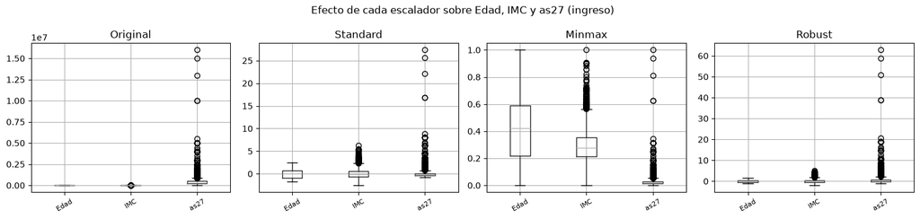

```python
fig, ejes = plt.subplots(1, 4, figsize=(15, 3.6))
for eje, (nombre, valores) in zip(ejes, resultados.items()):
    valores.boxplot(ax=eje)
    eje.set_title(nombre.capitalize())
    eje.tick_params(axis="x", rotation=30, labelsize=8)
plt.suptitle("Efecto de cada escalador sobre Edad, IMC y as27 (ingreso)")
plt.tight_layout()
plt.show()
```

```python
def verificar_escalamiento(valores, metodo, tol=1e-9):
    """Comprueba que el escalamiento produjo lo que el metodo promete."""
    if metodo == "standard":
        assert np.allclose(valores.mean(), 0, atol=tol), "media distinta de 0"
        assert np.allclose(valores.std(ddof=0), 1, atol=tol), "desviacion distinta de 1"
        return "media ~ 0 y desviacion ~ 1"
    if metodo == "minmax":
        assert np.allclose(valores.min(), 0, atol=tol), "minimo distinto de 0"
        assert np.allclose(valores.max(), 1, atol=tol), "maximo distinto de 1"
        return "todos los valores en el rango [0, 1]"
    if metodo == "robust":
        assert np.allclose(valores.median(), 0, atol=1e-8), "mediana distinta de 0"
        ric = valores.quantile(0.75) - valores.quantile(0.25)
        assert np.allclose(ric, 1, atol=1e-8), "rango intercuartilico distinto de 1"
        return "mediana ~ 0 y rango intercuartilico ~ 1"
    raise ValueError(f"Metodo desconocido: {metodo}")


for metodo in ["standard", "minmax", "robust"]:
    print(f"[OK] {metodo:<9} {verificar_escalamiento(resultados[metodo]['as27'], metodo)}")
```

```
[OK] standard  media ~ 0 y desviacion ~ 1
[OK] minmax    todos los valores en el rango [0, 1]
[OK] robust    mediana ~ 0 y rango intercuartilico ~ 1
```

## 7. Validación técnica y verificación del código

`validar_dataset` comprueba, con `assert`, que el resultado es correcto:

1. **Integridad** — sin valores nulos fuera de los documentados como faltante genuino (`as27`, `as28`; ver sección 4, decisiones c y e).
2. **Consistencia** — todas las columnas son numéricas.
3. **Coherencia** — cada grupo *one-hot* suma exactamente 1 por fila.
4. **Duplicados** — cuántas filas repetidas hay.
5. **Dimensiones** — la forma final de la tabla.

```python
def validar_dataset(df, grupos_one_hot=None, nulos_esperados=None):
    """
    Comprueba integridad, consistencia y coherencia del dataset final.
    Lanza AssertionError si alguna comprobacion falla.

    Parametros
    ----------
    nulos_esperados : dict, opcional
        {columna: cantidad esperada de nulos} para columnas que se dejaron
        con faltantes genuinos a proposito (seccion 4). Cualquier nulo fuera
        de estas columnas, o una cantidad distinta a la esperada, hace
        fallar la validacion: no es "permitir nulos", es verificar que son
        exactamente los documentados.
    """
    print("VALIDACION DEL DATASET FINAL")
    print("-" * 45)

    nulos_esperados = nulos_esperados or {}
    nulos_por_columna = df.isnull().sum()
    nulos_inesperados = {
        col: int(n) for col, n in nulos_por_columna.items()
        if n > 0 and n != nulos_esperados.get(col, 0)
    }
    assert not nulos_inesperados, f"Nulos no esperados o en cantidad distinta: {nulos_inesperados}"
    for col, n_esperado in nulos_esperados.items():
        n_real = int(nulos_por_columna.get(col, 0))
        assert n_real == n_esperado, f"'{col}': se esperaban {n_esperado} nulos, hay {n_real}."
    total_nulos = int(nulos_por_columna.sum())
    if nulos_esperados:
        print(f"[OK] {total_nulos} nulos en total, todos documentados como faltante genuino: {nulos_esperados}")
    else:
        print(f"[OK] Sin valores nulos (total = {total_nulos})")

    no_numericas = df.select_dtypes(exclude=[np.number]).columns.tolist()
    assert not no_numericas, f"Columnas no numericas: {no_numericas}"
    print("[OK] Todas las columnas son numericas")

    if grupos_one_hot:
        for nombre, cols in grupos_one_hot.items():
            suma = df[cols].sum(axis=1)
            assert (suma == 1).all(), f"El grupo '{nombre}' no suma 1 en todas las filas."
            print(f"[OK] Grupo one-hot '{nombre}' coherente")

    dup = int(df.duplicated().sum())
    print(f"[INFO] Filas duplicadas: {dup}")
    print(f"[INFO] Dimensiones finales: {df.shape}")
    return True


grupos = {
    "Sexo": ["Sexo_Hombre", "Sexo_Mujer"],
    "Zona": ["Zona_Urbano", "Zona_Rural"],
    "di3": ["di3_Si", "di3_No", "di3_No_recuerda"],
    "dis2": ["dis2_Si_una_vez", "dis2_Si_mas_de_una_vez", "dis2_Nunca", "dis2_No_recuerda"],
}
# as27 y as28 se dejaron con 816 nulos a proposito (seccion 4, decisiones c y e):
# es la misma no respuesta economica en ambas, documentada, no un descuido.
nulos_esperados = {"as27": 816, "as28": 816}
validar_dataset(df, grupos, nulos_esperados)
```

```
VALIDACION DEL DATASET FINAL
---------------------------------------------
[OK] 1632 nulos en total, todos documentados como faltante genuino: {'as27': 816, 'as28': 816}
[OK] Todas las columnas son numericas
[OK] Grupo one-hot 'Sexo' coherente
[OK] Grupo one-hot 'Zona' coherente
[OK] Grupo one-hot 'di3' coherente
[OK] Grupo one-hot 'dis2' coherente
[INFO] Filas duplicadas: 0
[INFO] Dimensiones finales: (5511, 23)
```

```
True
```

Sobre "no aplica". Ninguna de las seis variables revisadas depende de un salto condicional del cuestionario (una pregunta que solo se hace si la persona respondió algo específico antes): `as27`, `as28`, `HTA`, `di3`, `dis2` y `GPAQ` se preguntan a toda persona encuestada dentro de su formulario correspondiente. Por eso no existe, para estas variables, la categoría "no aplica" que menciona el libro de códigos para otras preguntas del cuestionario — y no corresponde inventarla ni tratarla como si estuviera presente.

### Pruebas de las funciones (casos normal, límite y excepciones)

Además de validar el *dataset*, se prueban por separado las funciones nuevas de este cuaderno en tres escenarios: caso normal, y las dos excepciones que cada una declara.

```python
# --- codificar_one_hot: caso normal ---
prueba = pd.DataFrame({"color": ["rojo", "azul", "rojo", "verde"]})
res = codificar_one_hot(prueba, "color", ["azul", "rojo", "verde"])
assert res.shape == (4, 3), "Numero de columnas inesperado."
assert (res.sum(axis=1) == 1).all(), "Cada fila debe tener una sola categoria activa."
print("[OK] codificar_one_hot: caso normal")

# --- codificar_one_hot: excepciones ---
try:
    codificar_one_hot(prueba, "color", ["azul", "rojo"])
except ValueError as e:
    print(f"[OK] codificar_one_hot: ValueError capturado ({e})")

try:
    codificar_one_hot(prueba, "inexistente", ["x"])
except KeyError as e:
    print(f"[OK] codificar_one_hot: KeyError capturado ({e})")

# --- marcar_codigos_no_respuesta: caso normal y limite ---
prueba2 = pd.DataFrame({"ingreso": [100, -9999, 200, -8888, 300]})
limpio = marcar_codigos_no_respuesta(prueba2, "ingreso")
assert limpio["ingreso"].isna().sum() == 2, "Debian marcarse 2 codigos especiales."
print("[OK] marcar_codigos_no_respuesta: caso normal")

sin_codigos = pd.DataFrame({"ingreso": [100, 200, 300]})
resultado_sin_cambios = marcar_codigos_no_respuesta(sin_codigos, "ingreso")
assert resultado_sin_cambios["ingreso"].isna().sum() == 0, "No debia marcar nada (caso limite)."
print("[OK] marcar_codigos_no_respuesta: caso limite (sin codigos presentes)")

try:
    marcar_codigos_no_respuesta(prueba2, "inexistente")
except KeyError as e:
    print(f"[OK] marcar_codigos_no_respuesta: KeyError capturado ({e})")

# --- imputar_nulos_categoricos: caso normal y excepcion ---
prueba3 = pd.DataFrame({"nivel": [1, 2, 2, np.nan, 2, 1]})
imputado = imputar_nulos_categoricos(prueba3, "nivel", estrategia="moda")
assert imputado["nivel"].isna().sum() == 0, "No debian quedar nulos."
assert imputado.loc[3, "nivel"] == 2, "Debia imputarse con la moda (2)."
print("[OK] imputar_nulos_categoricos: caso normal")

try:
    imputar_nulos_categoricos(prueba3, "nivel", estrategia="media")
except ValueError as e:
    print(f"[OK] imputar_nulos_categoricos: ValueError capturado ({e})")
```

```
[OK] codificar_one_hot: caso normal
[OK] codificar_one_hot: ValueError capturado (Se esperaban 3 nombres para 'color' (['azul', 'rojo', 'verde']), pero se recibieron 2.)
[OK] codificar_one_hot: KeyError capturado ("La columna 'inexistente' no existe en el DataFrame.")
'ingreso': 2 valores con codigo de no respuesta marcados como NaN
[OK] marcar_codigos_no_respuesta: caso normal
'ingreso': 0 valores con codigo de no respuesta marcados como NaN
[OK] marcar_codigos_no_respuesta: caso limite (sin codigos presentes)
[OK] marcar_codigos_no_respuesta: KeyError capturado ("La columna 'inexistente' no existe en el DataFrame.")
'nivel': 1 nulos imputados con la moda = 2.0
[OK] imputar_nulos_categoricos: caso normal
[OK] imputar_nulos_categoricos: ValueError capturado (estrategia debe ser 'moda')
```

### Visualización de control

El *boxplot* de las tres variables continuas ya estandarizadas confirma que quedaron centradas en torno a 0 y en una escala comparable entre sí.

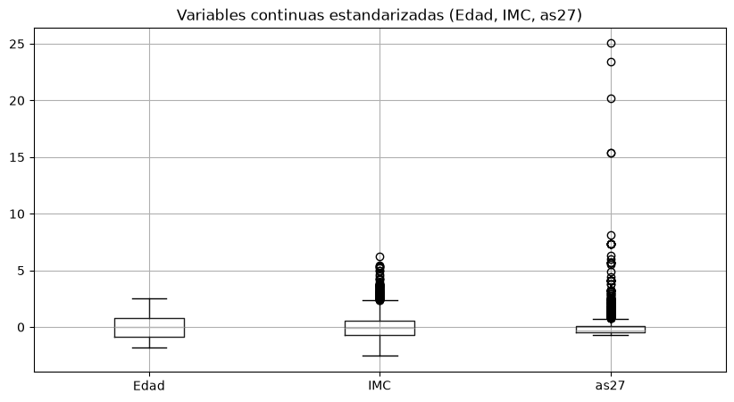

```python
df[columnas_continuas].boxplot(figsize=(10, 5))
plt.title("Variables continuas estandarizadas (Edad, IMC, as27)")
plt.show()
```

Vista final del *dataset* completamente preprocesado:

```python
print("Dataset final:", df.shape)
df.head()
```

```
Dataset final: (5511, 23)
```

|  | Edad | HTA | IMC | anos_estudio_MINSAL_1 | GPAQ | as27 | as28 | Fexp_F1F2p_Corr | Conglomerado | Estrato | ... | Sexo_Mujer | Zona_Urbano | Zona_Rural | di3_Si | di3_No | di3_No_recuerda | dis2_Si_una_vez | dis2_Si_mas_de_una_vez | dis2_Nunca | dis2_No_recuerda |
| --- | --- | --- | --- | --- | --- | --- | --- | --- | --- | --- | --- | --- | --- | --- | --- | --- | --- | --- | --- | --- | --- |
| 0 | -1.256904 | 0 | -1.031300 | 15.0 | 3 | -0.433713 | 3 | 52.307503 | 13101101 | 131 | ... | 1 | 1 | 0 | 0 | 1 | 0 | 0 | 0 | 1 | 0 |
| 1 | -1.516452 | 0 | -0.490394 | 14.0 | 3 | NaN | <NA> | 250.753357 | 13101102 | 131 | ... | 1 | 1 | 0 | 0 | 1 | 0 | 0 | 0 | 1 | 0 |
| 2 | 1.857664 | 1 | -0.935179 | 15.0 | 1 | 1.339974 | 10 | 133.128342 | 13101102 | 131 | ... | 1 | 1 | 0 | 0 | 1 | 0 | 0 | 1 | 0 | 0 |
| 3 | -0.997357 | 0 | -0.704314 | 16.0 | 3 | NaN | <NA> | 140.833298 | 13101102 | 131 | ... | 1 | 1 | 0 | 0 | 1 | 0 | 0 | 0 | 1 | 0 |
| 4 | 0.196561 | 0 | 0.604864 | 14.0 | 1 | NaN | <NA> | 97.582199 | 13101102 | 131 | ... | 1 | 1 | 0 | 0 | 1 | 0 | 0 | 0 | 1 | 0 |

5 rows × 23 columns

## Conclusiones y trazabilidad

**Trazabilidad con el repositorio (F2):** este cuaderno vive en `F2/notebooks/` y regenera, siempre desde `data/raw/ens2016.xlsx`, los mismos archivos que `F1/notebooks/S1_F1_Definicion.ipynb` reconoce al auditar la estructura del repositorio. El `README` documenta las dependencias y las instrucciones de ejecución.

## 8. Recursividad: aplanar los metadatos del proyecto

Todo el procesamiento anterior fue **estructurado**: secuencias, condicionales y bucles. Esta sección usa **recursividad**, la herramienta natural cuando la estructura tiene profundidad desconocida.

El caso es real: los metadatos del proyecto forman un diccionario anidado y, para exportarlos como tabla, hay que convertirlos en pares clave-valor. Un bucle no sirve porque no se sabe de antemano cuántos niveles de anidamiento tiene.

**Anatomía de la función recursiva:**

- *Caso base*: el valor no es un diccionario → se devuelve el par clave-valor.
- *Caso recursivo*: el valor es un diccionario → la función se llama a sí misma un nivel más abajo, arrastrando el prefijo de la ruta.

```python
METADATOS = {
    "proyecto": {
        "titulo": "Factores sociodemograficos y riesgo cardiovascular",
        "fase": "F2",
        "semilla": SEMILLA,
    },
    "datos": {
        "archivo_origen": "ens2016.xlsx",
        "fuente": {
            "institucion": "MINSAL - Departamento de Epidemiologia",
            "encuesta": "ENS 2016-2017",
        },
        "ponderador": "Fexp_F1F2p_Corr",
        "n_filas_final": int(df.shape[0]),
    },
    "decisiones": {
        "codigos_no_respuesta": {"as28": "-9999 marcado como NaN"},
        "filas_eliminadas": {"HTA_nulo": 9},
        "imputacion": {
            "IMC": "mediana",
            "anos_estudio_MINSAL_1": "mediana",
            "GPAQ": "moda",
            "as27_parcial": "mediana por tramo de as28 (177 casos sin monto, con tramo conocido)",
        },
        "faltantes_genuinos_no_imputados": {
            "as27": "816 nulos (misma no respuesta economica que as28, no aleatoria)",
            "as28": "816 nulos (no respuesta de ingreso; ver as28_no_responde)",
        },
        "reclasificacion": {"GPAQ": "de nominal (equipo) a ordinal (este cuaderno)"},
        "escalador": "standard",
        "variables_no_transformadas": ["Fexp_F1F2p_Corr", "Conglomerado", "Estrato"],
    },
}


def aplanar(estructura, prefijo="", separador="."):
    """Aplana un diccionario anidado en uno de un solo nivel.

    Ejemplo
    -------
    >>> aplanar({"a": {"b": 1, "c": {"d": 2}}})
    {'a.b': 1, 'a.c.d': 2}
    """
    plano = {}
    for clave, valor in estructura.items():
        ruta = f"{prefijo}{separador}{clave}" if prefijo else str(clave)
        if isinstance(valor, dict):
            plano.update(aplanar(valor, ruta, separador))          # CASO RECURSIVO
        elif isinstance(valor, (list, tuple)):
            plano[ruta] = ", ".join(str(v) for v in valor)
        else:
            plano[ruta] = valor                                     # CASO BASE
    return plano


metadatos_planos = aplanar(METADATOS)
print(f"El diccionario anidado se aplano en {len(metadatos_planos)} pares.\n")
for clave, valor in metadatos_planos.items():
    print(f"  {clave:<38} {str(valor)[:52]}")
```

```
El diccionario anidado se aplano en 19 pares.

  proyecto.titulo                        Factores sociodemograficos y riesgo cardiovascular
  proyecto.fase                          F2
  proyecto.semilla                       2026
  datos.archivo_origen                   ens2016.xlsx
  datos.fuente.institucion               MINSAL - Departamento de Epidemiologia
  datos.fuente.encuesta                  ENS 2016-2017
  datos.ponderador                       Fexp_F1F2p_Corr
  datos.n_filas_final                    5511
  decisiones.codigos_no_respuesta.as28   -9999 marcado como NaN
  decisiones.filas_eliminadas.HTA_nulo   9
  decisiones.imputacion.IMC              mediana
  decisiones.imputacion.anos_estudio_MINSAL_1 mediana
  decisiones.imputacion.GPAQ             moda
  decisiones.imputacion.as27_parcial     mediana por tramo de as28 (177 casos sin monto, con
  decisiones.faltantes_genuinos_no_imputados.as27 816 nulos (misma no respuesta economica que as28, no
  decisiones.faltantes_genuinos_no_imputados.as28 816 nulos (no respuesta de ingreso; ver as28_no_resp
  decisiones.reclasificacion.GPAQ        de nominal (equipo) a ordinal (este cuaderno)
  decisiones.escalador                   standard
  decisiones.variables_no_transformadas  Fexp_F1F2p_Corr, Conglomerado, Estrato
```

```python
assert aplanar({"a": 1}) == {"a": 1}, "Caso plano"
assert aplanar({"a": {"b": 1}}) == {"a.b": 1}, "Un nivel de anidamiento"
assert aplanar({"a": {"b": {"c": {"d": 4}}}}) == {"a.b.c.d": 4}, "Anidamiento profundo"
assert aplanar({}) == {}, "Caso limite: diccionario vacio"
assert aplanar({"x": [1, 2, 3]}) == {"x": "1, 2, 3"}, "Listas convertidas a texto"
print("[OK] La funcion recursiva pasa las cinco pruebas.")
```

```
[OK] La funcion recursiva pasa las cinco pruebas.
```

> **Cuándo NO usar recursividad.** Si la profundidad se conoce y es fija, un bucle anidado es más claro y más rápido. Se justifica aquí porque la profundidad de `METADATOS` es variable.

## 9. Persistencia y trazabilidad

El resultado debe quedar guardado y documentado: es la entrada directa de la Fase 3.

```python
ARCHIVO_PROCESADO = DIR_PROCESADO / "ens_procesado.csv"
df.to_csv(ARCHIVO_PROCESADO, index=False)

# Verificacion de ida y vuelta: se relee lo guardado y se comprueba que coincide.
releido = pd.read_csv(ARCHIVO_PROCESADO)
assert releido.shape == df.shape, "El archivo releido no coincide en dimensiones"
print(f"Guardado y verificado: {ARCHIVO_PROCESADO}")
print(f"Tamano en disco: {ARCHIVO_PROCESADO.stat().st_size / 1024:.1f} kB")

pd.DataFrame(list(metadatos_planos.items()), columns=["clave", "valor"]).to_csv(
    DIR_DOCS / "metadatos_proyecto.csv", index=False)
print(f"Metadatos exportados a {DIR_DOCS / 'metadatos_proyecto.csv'}")
```

```
Guardado y verificado: /Users/felipekaysdiaztoro/proyecto-grupo4-mcdi500/data/processed/ens_procesado.csv
Tamano en disco: 656.9 kB
Metadatos exportados a /Users/felipekaysdiaztoro/proyecto-grupo4-mcdi500/F2/docs/metadatos_proyecto.csv
```

```python
resumen = pd.DataFrame([
    {"indicador": "Filas", "inicial": df_crudo.shape[0], "final": df.shape[0]},
    {"indicador": "Columnas", "inicial": df_crudo.shape[1], "final": df.shape[1]},
    {"indicador": "Valores nulos",
     "inicial": int(df_crudo.isna().sum().sum()), "final": int(df.isna().sum().sum())},
    {"indicador": "Columnas no numericas",
     "inicial": int(df_crudo.select_dtypes(exclude=[np.number]).shape[1]),
     "final": int(df.select_dtypes(exclude=[np.number]).shape[1])},
    {"indicador": "Filas duplicadas",
     "inicial": int(df_crudo.duplicated().sum()), "final": int(df.duplicated().sum())},
])
resumen
```

|  | indicador | inicial | final |
| --- | --- | --- | --- |
| 0 | Filas | 5520 | 5511 |
| 1 | Columnas | 16 | 23 |
| 2 | Valores nulos | 1284 | 1632 |
| 3 | Columnas no numericas | 1 | 0 |
| 4 | Filas duplicadas | 0 | 0 |

## 10. Reflexión técnica

### Hallazgos

- **Solo `as28` usa realmente códigos de no respuesta.** De las seis variables candidatas (`as27`, `as28`, `di3`, `dis2`, `HTA`, `GPAQ`), únicamente `as28` contenía el código `-9999`; `-8888` no aparece en ninguna. Verificarlo evitó aplicar un tratamiento innecesario a variables que no lo requerían.
- **`as27` y `as28` comparten la misma no respuesta económica, y eso cambió cómo se tratan.** Cruzar ambas variables mostró que los 816 casos sin dato en `as28` (código `-9999`) son exactamente los mismos que quedan sin dato en `as27`: no son dos fallas independientes. Imputar cualquiera de las dos con un valor típico (moda o mediana) habría escondido un posible sesgo de no respuesta concentrado en los extremos de ingreso. Se dejan como faltante genuino donde el patrón está verificado (esos 816 casos en ambas variables), y se imputa solo donde hay información real disponible: los otros 177 nulos de `as27` sí tienen un tramo de `as28` conocido, así que se imputan con la mediana dentro de ese tramo. El mismo criterio se evaluó para `GPAQ` (también ordinal, también con nulos) y se descartó: ahí la duda sobre el mecanismo es especulativa, no verificada, y el costo de imputar mal es bajo (3,6 % de nulos), así que se mantiene la imputación por moda.
- **`GPAQ` estaba mal clasificado.** El equipo lo declaró "nominal" en la Fase 1, pero es una escala ordinal (Bajo < Moderado < Alto). Tratarlo como nominal con *one-hot* habría descartado esa información de orden sin necesidad.

### Dificultades y cómo se resolvieron

- **Rutas relativas frágiles.** La versión anterior de este cuaderno mezclaba rutas relativas al directorio de trabajo (`data/raw`) con búsquedas hacia arriba (`Path.cwd().parent`), lo que dependía de desde dónde se abriera Jupyter. Se reemplazó por `encontrar_raiz_proyecto()` — la misma función que ya usa la Fase 1 — para que el cuaderno corra igual sin importar la carpeta de trabajo.
- di3 y dis2 con categorías de incertidumbre. Sus categorías minoritarias se verificaron contra el libro de códigos F1: `di3=3` y `dis2=4` significan "No recuerda", una respuesta de incertidumbre real, no un vacío ni una respuesta negativa. Se codificaron con su nombre real (`di3_No_recuerda`, `dis2_No_recuerda`) en vez de fusionarlas con las categorías negativas.

### Decisiones que quedan abiertas

- Si `as27` debería escalarse con `RobustScaler` en vez de `StandardScaler`, dada su asimetría.
- Si el análisis de la Fase 3 usará `Conglomerado`, `Estrato` y `Fexp_F1F2p_Corr` para un análisis con diseño muestral complejo, o solo el ponderador de forma simple.
- Si vale la pena extender `comparar_imputaciones()` para soportar un agrupador ya categórico (sin `qcut`), y así comparar con cifras "mediana por edad" vs. "mediana por tramo de `as28`" para los 177 casos — hoy esa elección se argumenta en sección 2 pero no se demuestra con una tabla, a diferencia del resto de las decisiones de este cuaderno.

> **Declarar lo que queda abierto evidencia más dominio que presentar todo resuelto.**

## 11. Verificación antes de entregar

**Notebook**

- Corre completo tras *Kernel → Restart Kernel and Run All Cells*, sin errores.
- La numeración de ejecución es continua.
- Cada bloque de código está precedido por una celda narrativa que explica su lógica.
- Todas las rutas se resuelven desde la raíz del repositorio (`encontrar_raiz_proyecto`) y la semilla está declarada.

**Contenido técnico**

- La procedencia del conjunto está documentada, con cita en APA 7.
- El diccionario de variables declara el rol analítico de cada una y documenta la reclasificación de `GPAQ`.
- Los códigos especiales de no respuesta se verificaron por variable, no se asumieron.
- Las decisiones de imputación y escalamiento están comparadas y justificadas con cifras del propio conjunto.
- Los faltantes genuinos que quedan a propósito (`as27`, `as28`: 816 cada una) están documentados y verificados por `validar_dataset()`, no son un descuido.
- Hay pruebas de casos normales, límite y excepciones para cada función nueva.

**Archivos**

- `data/raw/ens2016.xlsx` conserva el archivo original sin modificar.
- `data/processed/` contiene `ens_variables_seleccionadas.xlsx`, `ens_variables_f1f2.xlsx` y `ens_procesado.csv` (entrada directa de la Fase 3).
- `F2/docs/` contiene el diccionario de variables, el resumen del filtro y los metadatos.

**Repositorio**

- Carpeta `F2/notebooks/` con este cuaderno, y `README` actualizado con la estructura vigente.

*Cuaderno de la Fase 2 · MCDI500 · Magíster en Ciencia de Datos e Inteligencia Artificial · Universidad Andrés Bello*